# Reproducible Research: Peer-Assessed Project 2

Christopher Jones

11/16/2017

## Historical US Storm Data Analysis:

## A survey of historical storm data with respect to population health and economic consequences

### Synopsis

We examine historical US storm data from NOAA covering 1950-2011, to assess types of events that are most harmful to human health, and also which types of events have the greatest economic consequences. Many nominally distinct event types are similar (e.g. different types of floods). We here report the storm event types as presented in the data, and do not go beyond the data by attempting to amalgamate similar types.

Primary findings:

- Tornadoes are the largest historical contributor to weather event fatalities, at 37% of the 15,145 total.
- Tornadoes are also the largest historical cause of weather event injury, at 65% of the 140,528 total.
- Drought is the largest cause of crop damage at almost ~$14 billion of the ~$49 billion total.
- Flooding is the largest cause of property damage at ~$144.5 billion of the ~427 billion total.
- A fuller analysis would need to take into account variables like geography, date, age, gender, and currency depreciation.

### Data Loading/Processing

#### Data Loading:

Loading the data is simple; the code is more lengthy because it is general-purpose, checking for the minimal amount of work to be done to load (need download? need unzip? only need to read the file?).

First we load the packages to be used in this report.

```r
# packages we'll be using
library(plyr)
library(ggplot2)
library(grid)
library(gridBase)
library(treemap)
library(scales)
library(formattable)
```

Next we load the storm data into memory. This code includes multiple checks to load the data with a minimum of effort.

```r
# =======================
# Data loader
# =======================



# download data if it isn't already in place in current directory
filename <- "repdata_data_StormData"
extension.data <- ".csv"
extension.zip <- ".bz2"
zipurl <- "https://d396qusza40orc.cloudfront.net/repdata%2Fdata%2FStormData.csv.bz2"

if (!file.exists(paste(filename, extension.data, sep='')))
{
  message("Data file not found, checking for data zip file
          ")
  if (!file.exists(paste(c(filename, extension.data, extension.zip), collapse='')))
  {
    message("Data zip file not found. Downloading.")

    download <- download.file(zipurl, destfile=paste(c(filename, extension.data, extension.zip), collapse=''))
    foundzip <- TRUE

    message("Data zip file downloaded.")
  } else
  {
    foundzip <- TRUE
  }

  if (foundzip)
  {
    message("Found data zip file, unzipping.")

    library(R.utils)
    bunzip2(paste(c(filename, extension.data, extension.zip), collapse='')
            , paste(c(filename, extension.data), collapse='')
            , remove = FALSE
            , overwrite = TRUE
            )
    unlink(paste(filename, extension.zip, sep=''))

    message("Data zip file unzipped.")
  }

  if (file.exists(paste(filename, extension.data, sep='')))
  {
    message("Data file exists, ready for preprocessing")
  } else
  {
    stop("Data file not found, reason unknown. Halting execution.")
  }
}

# read data only if not already loaded
readdata <- TRUE
if (exists("data.raw"))
{
  if(nrow(data.raw) == 902297) # hardcoding numbers is bad m'kay?
  {
    readdata <- FALSE
  }
}
if (readdata)
{
  message("Reading data file:")
  data.raw <- read.csv(paste(filename, extension.data, sep=''), header=TRUE)
}
```

```
## Reading data file:
```

```r
message("Raw data loaded.")
```

```
## Raw data loaded.
```

#### Data Processing:

Next we perform data processing. For the multiple output analyses required, this is somewhat lengthy, but not complicated.

The following steps are performed in the below code chunks:

1. Subset the data with only the fields needed for this project
2. For the economic damage, convert order of magnitude exponents into complete dollar amounts
3. Summarize into aggregate totals
4. There are many (~1,000) distinct storm events, to to aid the user in focussing on the highest impact events, we do the following:
   - For economic analysis, remove events which have no property or crop damage
   - For health analysis, remove events which have no deaths or injuries
   - For each analysis, order the events by descending dollar/fatality/injury value, and take events from the top until a THRESHHOLD of 85% of the total loss is reached. The remaining events are then lumped into an Other category and included in the output. This THRESHHOLD computation is implemented by the creation of running total/percentage columns to the aggregated data.

Processing common to both health and economic analyses:

```r
#===========================
# Data processing - common
#===========================

# project out the columns we're interested in
data.proc <- data.raw[,c("EVTYPE", "FATALITIES", "INJURIES", "PROPDMG","PROPDMGEXP","CROPDMG","CROPDMGEXP")]
```

Processing for only economic analyses:

```r
# perform order of magnitude calculation to get actual dollar amounts for prop & crop damage
data.proc$prop_dmg <- data.proc$PROPDMG * sapply(data.proc$PROPDMGEXP, function(str_exp) {switch(tolower(str_exp), "h" = 100, "k" = 1000, "m" = 1000000, "b" = 1000000000, if (is.numeric(str_exp)) 10 ** as.numeric(str_exp) else 1)})
data.proc$crop_dmg <- data.proc$CROPDMG * sapply(data.proc$CROPDMGEXP, function(str_exp) {switch(tolower(str_exp), "h" = 100, "k" = 1000, "m" = 1000000, "b" = 1000000000, if (is.numeric(str_exp)) 10 ** as.numeric(str_exp) else 1)})

# create totals by event for prop & crop damage value
econ_dmg <- ddply(data.proc, .(EVTYPE), summarize, prop_dmg = sum(prop_dmg), crop_dmg = sum(crop_dmg))

# only interested in events with damage
econ_dmg <- econ_dmg[(econ_dmg$prop_dmg > 0 | econ_dmg$crop_dmg > 0), ]

# create running total and % of total
propDmgSorted <- econ_dmg[order(econ_dmg$prop_dmg, decreasing = T), ]
propDmgSorted$cum <- cumsum(propDmgSorted$prop_dmg)
propDmgSorted$running_pct <- propDmgSorted$cum / sum(propDmgSorted$prop_dmg)

cropDmgSorted <- econ_dmg[order(econ_dmg$crop_dmg, decreasing = T), ]
cropDmgSorted$cum <- cumsum(cropDmgSorted$crop_dmg)
cropDmgSorted$running_pct <- cropDmgSorted$cum / sum(cropDmgSorted$crop_dmg)

head(propDmgSorted[, c("EVTYPE", "prop_dmg")], 5)
```

```
##                EVTYPE     prop_dmg
## 170             FLOOD 144657709807
## 411 HURRICANE/TYPHOON  69305840000
## 834           TORNADO  56937160779
## 670       STORM SURGE  43323536000
## 153       FLASH FLOOD  16140812067
```

```r
head(cropDmgSorted[, c("EVTYPE", "crop_dmg")], 5)
```

```
##          EVTYPE    crop_dmg
## 95      DROUGHT 13972566000
## 170       FLOOD  5661968450
## 590 RIVER FLOOD  5029459000
## 427   ICE STORM  5022113500
## 244        HAIL  3025954473
```

```r
# we take 90% of total damage as threshhold to include in report,
# and create an Other event category for the rest.
threshhold <- .85

# property damage report data
propDmgReportData <- propDmgSorted[propDmgSorted$running_pct <= threshhold, ]
propDmgReportData <- rbind(propDmgReportData, c("Other"
                                              , sum(propDmgSorted$prop_dmg) - max(propDmgReportData$cum)
                                              , 0
                                              , sum(propDmgSorted$prop_dmg)
                                              , 1
                                              )
                                            )
propDmgReportData$prop_dmg <- as.numeric(propDmgReportData$prop_dmg)
propDmgReportData$crop_dmg <- as.numeric(propDmgReportData$crop_dmg)
propDmgReportData$cum <- as.numeric(propDmgReportData$cum)
propDmgReportData$running_pct <- as.numeric(propDmgReportData$running_pct)
other_count_prop <- as.character(nrow(propDmgSorted) - nrow(propDmgReportData) + 1)
propDmgReportData$event_pct <- paste(ifelse(propDmgReportData$EVTYPE != "Other", as.character(propDmgReportData$EVTYPE), paste("Other", paste("(", other_count_prop, ")", sep=""), sep=" "))
                                     , currency(propDmgReportData$prop_dmg, digits=0L)
                                     , percent(propDmgReportData$prop_dmg / sum(propDmgReportData$prop_dmg))
                                     , sep="\n"
                                    )

# crop damage report data
cropDmgReportData <- cropDmgSorted[cropDmgSorted$running_pct <= threshhold, ]
cropDmgReportData <- rbind(cropDmgReportData, c("Other"
                             , 0
                              , sum(cropDmgSorted$crop_dmg) - max(cropDmgReportData$cum)
                              , sum(cropDmgSorted$crop_dmg)
                              , 1
                              )
                            )
cropDmgReportData$prop_dmg <- as.numeric(cropDmgReportData$prop_dmg)
cropDmgReportData$crop_dmg <- as.numeric(cropDmgReportData$crop_dmg)
cropDmgReportData$cum <- as.numeric(cropDmgReportData$cum)
cropDmgReportData$running_pct <- as.numeric(cropDmgReportData$running_pct)
other_count_crop <- as.character(nrow(cropDmgSorted) - nrow(cropDmgReportData) + 1)
cropDmgReportData$event_pct <- paste(ifelse(cropDmgReportData$EVTYPE != "Other", as.character(cropDmgReportData$EVTYPE), paste("Other", paste("(", other_count_crop, ")", sep=""), sep=" "))
                                     , currency(cropDmgReportData$crop_dmg, digits=0L)
                                     , percent(cropDmgReportData$crop_dmg / sum(cropDmgReportData$crop_dmg))
                                     , sep="\n"
)

message("Economic damage report data created.")
```

```
## Economic damage report data created.
```

Processing for only health damage:

```r
# create totals by event for health damage
health_dmg <- ddply(data.proc, .(EVTYPE), summarize, fat = sum(FATALITIES), inj = sum(INJURIES))

# only interested in events with deaths or injuries
health_dmg <- health_dmg[(health_dmg$fat > 0 | health_dmg$inj > 0), ]

# create running total and % of total
fatSorted <- health_dmg[order(health_dmg$fat, decreasing = T), ]
injSorted <- health_dmg[order(health_dmg$inj, decreasing = T), ]

fatSorted$cum <- cumsum(fatSorted$fat)
injSorted$cum <- cumsum(injSorted$inj)

fatSorted$running_pct <- fatSorted$cum / sum(fatSorted$fat)
injSorted$running_pct <- injSorted$cum / sum(injSorted$inj)

head(fatSorted[, c("EVTYPE", "fat")], 5)
```

```
##             EVTYPE  fat
## 834        TORNADO 5633
## 130 EXCESSIVE HEAT 1903
## 153    FLASH FLOOD  978
## 275           HEAT  937
## 464      LIGHTNING  816
```

```r
head(injSorted[, c("EVTYPE", "inj")], 5)
```

```
##             EVTYPE   inj
## 834        TORNADO 91346
## 856      TSTM WIND  6957
## 170          FLOOD  6789
## 130 EXCESSIVE HEAT  6525
## 464      LIGHTNING  5230
```

```r
# we take the events totalling 85% of the fatalties/injuries
th_health <- .85

# fatality report data
fatReportData <- fatSorted[fatSorted$running_pct <= th_health, ]
fatReportData <- rbind(fatReportData, c("Other"
                                          , sum(fatSorted$fat) - max(fatReportData$cum)
                                          , 0
                                          , sum(fatSorted$fat)
                                          , 1
                                        )
                      )
fatReportData$fat <- as.numeric(fatReportData$fat)
fatReportData$inj <- as.numeric(fatReportData$inj)
fatReportData$cum <- as.numeric(fatReportData$cum)
fatReportData$running_pct <- as.numeric(fatReportData$running_pct)
other_count_fat <- as.character(nrow(fatSorted) - nrow(fatReportData) + 1)
fatReportData$event_pct <- paste(ifelse(fatReportData$EVTYPE != "Other", as.character(fatReportData$EVTYPE), paste("Other", paste("(", other_count_fat, ")", sep=""), sep=" "))
                                     , formatC(fatReportData$fat, format="d", big.mark=",")
                                     , percent(fatReportData$fat / sum(fatReportData$fat))
                                     , sep="\n"
)

# injury report data
injReportData <- injSorted[injSorted$running_pct <= th_health, ]
injReportData <- rbind(injReportData, c("Other"
                                          , 0
                                          , sum(injSorted$inj) - max(injReportData$cum)
                                          , sum(injSorted$inj)
                                          , 1
                                        )
                      )
injReportData$fat <- as.numeric(injReportData$fat)
injReportData$inj <- as.numeric(injReportData$inj)
injReportData$cum <- as.numeric(injReportData$cum)
injReportData$running_pct <- as.numeric(injReportData$running_pct)
other_count_inj <- as.character(nrow(injSorted) - nrow(injReportData) + 1)
injReportData$event_pct <- paste(ifelse(injReportData$EVTYPE != "Other", as.character(injReportData$EVTYPE), paste("Other", paste("(", other_count_inj, ")", sep=""), sep=" "))
                                     , formatC(injReportData$inj, format="d", big.mark=",")
                                     , percent(injReportData$inj / sum(injReportData$inj))
                                     , sep="\n"
                                )

message("Health damage report data created.")
```

```
## Health damage report data created.
```

### Results: Health

To easily visualize the comparative historical impacts of weather events, we use tree maps. Below are tree maps showing the fatalities and injuries from events.

As described earlier, the “Other” category is the catch-all for all the events remaining after those responsible for 85% of the fatalities/injuries we picked out.

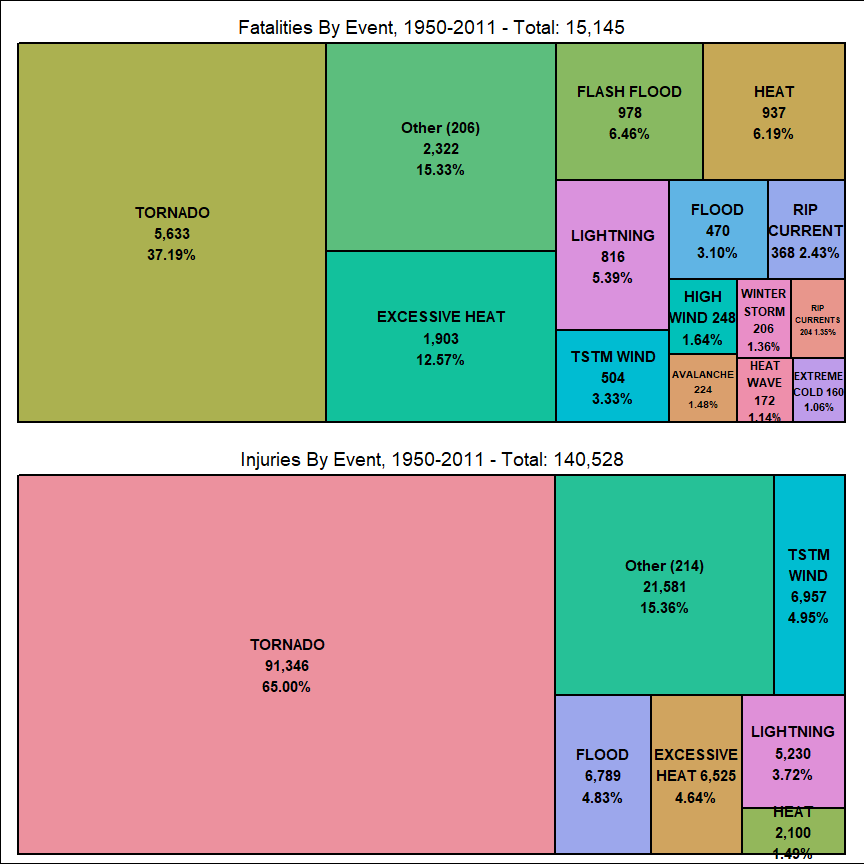

```r
# make health impact visualizations
par(oma=c(1, 1, 1, 1))
grid.newpage()
grid.rect()
pushViewport(viewport(layout=grid.layout(2, 1)))

vp1 <- viewport(layout.pos.col=1, layout.pos.row=1)
pushViewport(vp1)
treemap(fatReportData
        , index="event_pct"
        , vSize="fat"
        , type="index"
        , fontsize.title=14
        , title= paste("Fatalities By Event, 1950-2011 - Total: ", formatC(sum(fatSorted$fat), format="d", big.mark=","), sep='')
        , vp=vp1
)
popViewport()

vp2 <- viewport(layout.pos.col=1, layout.pos.row=2)
pushViewport(vp2)
treemap(injReportData
        , index="event_pct"
        , vSize="inj"
        , type="index"
        , fontsize.title=14
        , title= paste("Injuries By Event, 1950-2011 - Total: ", formatC(sum(injSorted$inj), format="d", big.mark=","), sep='')
        , vp=vp2
)
popViewport()
```

### Results: Economic

To easily visualize the comparative historical impacts of weather events, we again use tree maps. Below are tree maps showing the (unadjusted) USD value of crop and property damage from weather events.

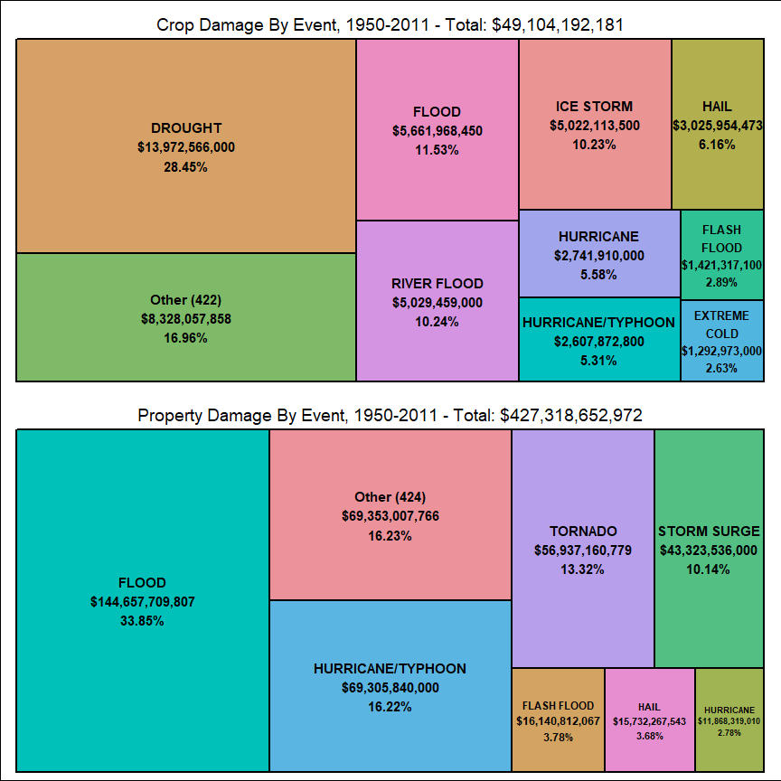

```r
# make economic damage visualization
par(oma=c(1, 1, 1, 1))
grid.newpage()
grid.rect()
pushViewport(viewport(layout=grid.layout(2, 1)))

vp1 <- viewport(layout.pos.col=1, layout.pos.row=1)
pushViewport(vp1)
treemap(cropDmgReportData
        , index='event_pct'
        , vSize='crop_dmg'
        , type='index'
        , fontsize.title=14
        , title= paste('Crop Damage By Event, 1950-2011 - Total: ', currency(sum(cropDmgSorted$crop_dmg), digits=0L), sep='')
        , vp=vp1
)
popViewport()

vp2 <- viewport(layout.pos.col=1, layout.pos.row=2)
pushViewport(vp2)
treemap(propDmgReportData
        , index='event_pct'
        , vSize='prop_dmg'
        , type='index'
        , fontsize.title=14
        , title= paste('Property Damage By Event, 1950-2011 - Total: ', currency(sum(propDmgSorted$prop_dmg), digits=0L), sep='')
        , vp=vp2
)
popViewport()
```

### References

Coursera page for this project: https://www.coursera.org/learn/reproducible-research/peer/OMZ37/course-project-2

My github repo for this project: https://github.com/seedjay1/RepData_PA2

Raw data used for the analysis: https://d396qusza40orc.cloudfront.net/repdata%2Fdata%2FStormData.csv.bz2

RPubs link for this report: http://rpubs.com/seedjay/sda